# March 2 Coronavirus Update

```r
library(ggplot2)
library(tidyverse)
```

## Good News from China. Not so much from other places.

As it is well known, the covid-19 started this january and emerged from the Hubei region in China. Now for the first time in the last couple of weeks the data is giving us reason to reason to believe that it is starting to fade, in China at least.

# Let’s start.

```r
load("F:/Escritorio/Bases de datos Daniel/Carper/CoronavirusenColombia_files/coronavirus.rda")
```

You can download Rami Krispin’s data from his GitHub.

```r
c1 <- coronavirus %>%
  select(date,type,cases,Country.Region) %>%
  group_by(date,type,Country.Region) %>%
  summarise(total_cases = sum(cases))

c2 <- as.data.frame(c1[which(c1$type=="confirmed" & c1$Country.Region == "Mainland China"),])

c2$day <- (1:length(c2$total_cases))

c2$corcumtotal_cases <- cumsum(c2$total_cases)
```

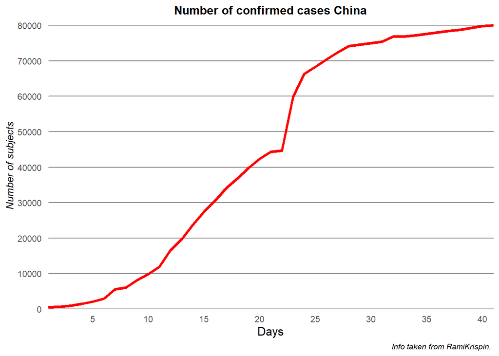

```r
PlotChinalin <- ggplot(c2, aes(day,corcumtotal_cases)) + geom_line(size=1.25,color="red1") +

  theme(
    plot.title = element_text(size = 12, face = "bold",hjust = 0.5),
    plot.caption = element_text(size = 8, face = "italic"),
    panel.grid.minor = element_blank(),
    panel.grid.major = element_line(color = "gray50", size = 0.5),
    panel.grid.major.x = element_blank(),
    panel.background = element_blank(),
    line = element_blank(),
    axis.ticks.length = unit(.15, "cm"),
    axis.ticks.y = element_blank(),
    axis.title.x = element_text(color="black",
    size=12),
    axis.title.y = element_text(color="black",
    size=10,
    face="italic"))+

  scale_y_continuous(expand = c(0, 0),
    limits=c(0.0,81000),
    breaks=seq(0.0,90000,10000),
    name = "Number of subjects")+

  scale_x_continuous(expand = c(0, 0),
    breaks=seq(0.0,40,5),
    name = "Days")+

  labs(title = "Number of confirmed cases China",
       caption = "Info taken from RamiKrispin. ")

PlotChinalin
```

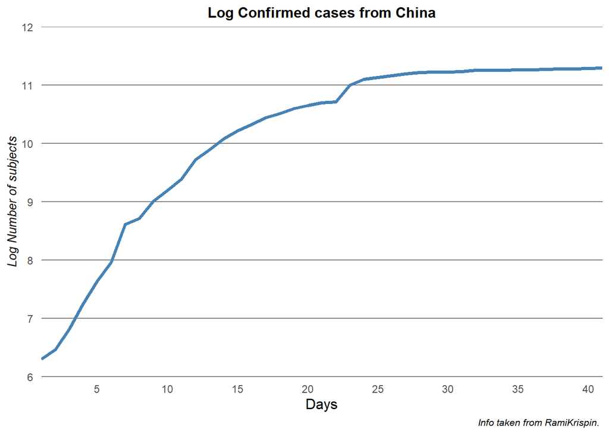

```r
PlotChinalog <- ggplot(c2, aes(day,log(corcumtotal_cases))) + geom_line(size=1.25, color= "steelblue")+

  theme(
    plot.title = element_text(size = 12, face = "bold",hjust = 0.5),
    plot.caption = element_text(size = 8, face = "italic"),
    panel.grid.minor = element_blank(),
    panel.grid.major = element_line(color = "gray50", size = 0.5),
    panel.grid.major.x = element_blank(),
    panel.background = element_blank(),
    line = element_blank(),
    axis.ticks.length = unit(.15, "cm"),
    axis.ticks.y = element_blank(),
    axis.title.x = element_text(color="black",
    size=12),
    axis.title.y = element_text(color="black",
    size=10,
    face="italic"))+

  scale_y_continuous(expand = c(0, 0),
    limits=c(6,12),
    breaks=seq(0.0,12,1),
    name = "Log Number of subjects")+

  scale_x_continuous(expand = c(0, 0),
    breaks=seq(0.0,40,5),
    name = "Days")+

  labs(title = "Log Confirmed cases from China",
       caption = "Info taken from RamiKrispin. ")
PlotChinalog
```

As you can see, the plot shows on a logarithmic scale that the rate of confirmed cases increase in the last two weeks is slowing down. Great news for China!

However, there are countries where the covid-19 is getting in a foothold, we will examine the data.

# South Korea

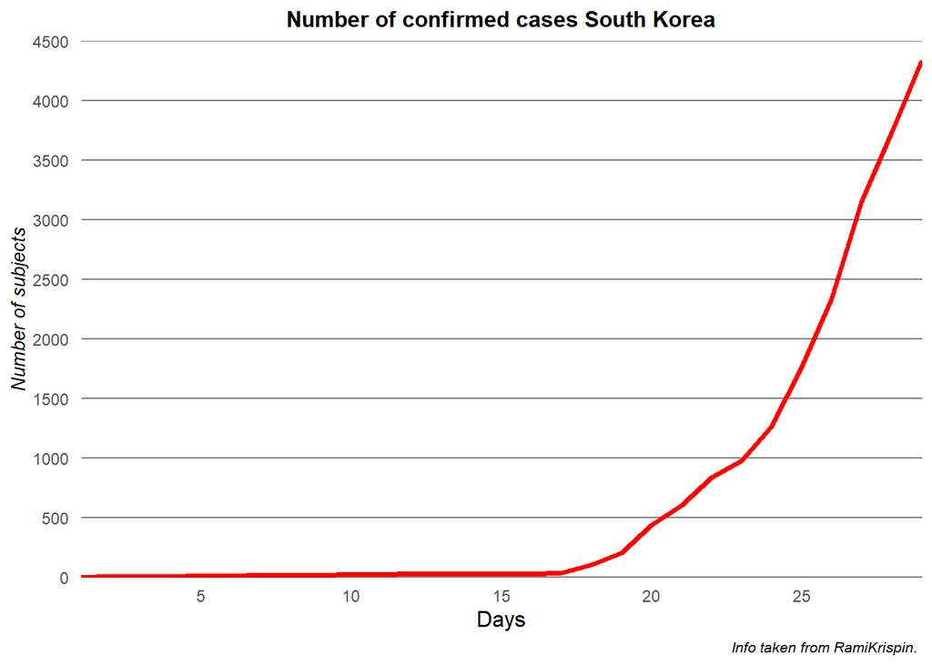

```r
c3 <- as.data.frame(c1[which(c1$type=="confirmed" & c1$Country.Region == "South Korea"),])

c3$day <- 1:length(c3$total_cases)

c3$corcumtotal_cases <- cumsum(c3$total_cases)

PlotKorea <- ggplot(c3, aes(day,corcumtotal_cases)) + geom_line(size=1.25,color="red1") +

  theme(
    plot.title = element_text(size = 12, face = "bold",hjust = 0.5),
    plot.caption = element_text(size = 8, face = "italic"),
    panel.grid.minor = element_blank(),
    panel.grid.major = element_line(color = "gray50", size = 0.5),
    panel.grid.major.x = element_blank(),
    panel.background = element_blank(),
    line = element_blank(),
    axis.ticks.length = unit(.15, "cm"),
    axis.ticks.y = element_blank(),
    axis.title.x = element_text(color="black",
    size=12),
    axis.title.y = element_text(color="black",
    size=10,
    face="italic"))+

  scale_y_continuous(expand = c(0, 0),
    limits=c(0.0,4500),
    breaks=seq(0.0,4500,500),
    name = "Number of subjects")+

  scale_x_continuous(expand = c(0, 0),
    breaks=seq(0.0,40,5),
    name = "Days")+

  labs(title = "Number of confirmed cases South Korea",
       caption = "Info taken from RamiKrispin. ")

PlotKorea
```

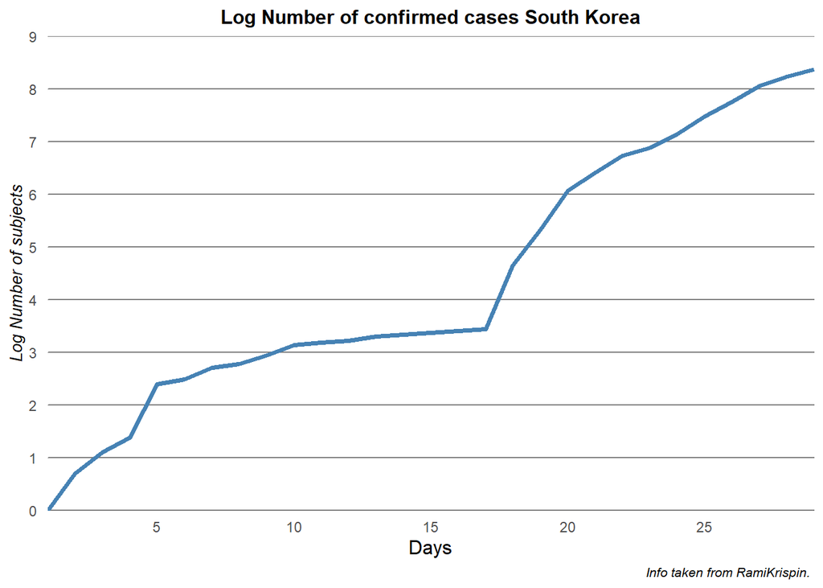

```r
PlotKorealog <- ggplot(c3, aes(day, log(corcumtotal_cases))) +geom_line(size=1.25,color="steelblue")+
    theme(
    plot.title = element_text(size = 12, face = "bold",hjust = 0.5),
    plot.caption = element_text(size = 8, face = "italic"),
    panel.grid.minor = element_blank(),
    panel.grid.major = element_line(color = "gray50", size = 0.5),
    panel.grid.major.x = element_blank(),
    panel.background = element_blank(),
    line = element_blank(),
    axis.ticks.length = unit(.15, "cm"),
    axis.ticks.y = element_blank(),
    axis.title.x = element_text(color="black",
    size=12),
    axis.title.y = element_text(color="black",
    size=10,
    face="italic"))+

  scale_y_continuous(expand = c(0, 0),
    limits=c(0.0,9),
    breaks=seq(0.0,9,1),
    name = "Log Number of subjects")+

  scale_x_continuous(expand = c(0, 0),
    breaks=seq(0.0,40,5),
    name = "Days")+

  labs(title = "Log Number of confirmed cases South Korea",
       caption = "Info taken from RamiKrispin. ")
PlotKorealog
```

When looking at the graphs South Korea is a whole different story, it started a little later than China but has picked up pace in the past couple of weeks. However do keep in mind the scale of both graphs, in China we were looking at a graph that went all the way to 80,000 while in Korea we are looking at one that barely breaks the 4,000 figure.

# Italy

```r
c4 <- as.data.frame(c1[which(c1$type=="confirmed" & c1$Country.Region == "Italy"),])

c4$day <- 1:length(c4$total_cases)

c4$corcumtotal_cases <- cumsum(c4$total_cases)
```

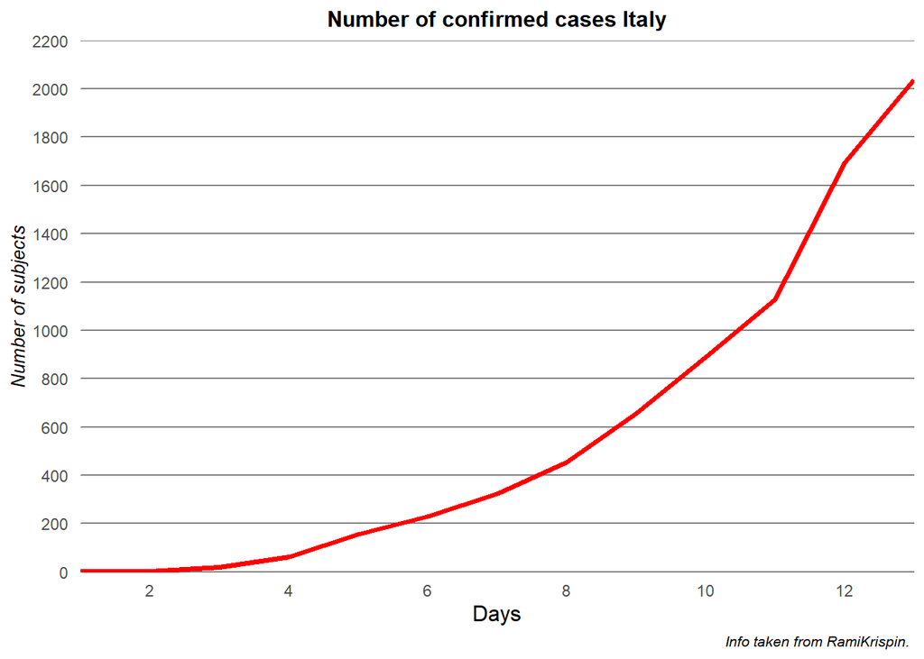

```r
PlotItalylin <- ggplot(c4, aes(day,corcumtotal_cases)) + geom_line(size=1.25,color="red1") +

  theme(
    plot.title = element_text(size = 12, face = "bold",hjust = 0.5),
    plot.caption = element_text(size = 8, face = "italic"),
    panel.grid.minor = element_blank(),
    panel.grid.major = element_line(color = "gray50", size = 0.5),
    panel.grid.major.x = element_blank(),
    panel.background = element_blank(),
    line = element_blank(),
    axis.ticks.length = unit(.15, "cm"),
    axis.ticks.y = element_blank(),
    axis.title.x = element_text(color="black",
    size=12),
    axis.title.y = element_text(color="black",
    size=10,
    face="italic"))+

  scale_y_continuous(expand = c(0, 0),
    limits=c(0.0,2200),
    breaks=seq(0.0,2200,200),
    name = "Number of subjects")+

  scale_x_continuous(expand = c(0, 0),
    breaks=seq(0.0,13,2),
    name = "Days")+

  labs(title = "Number of confirmed cases Italy",
       caption = "Info taken from RamiKrispin. ")
PlotItalylin
```

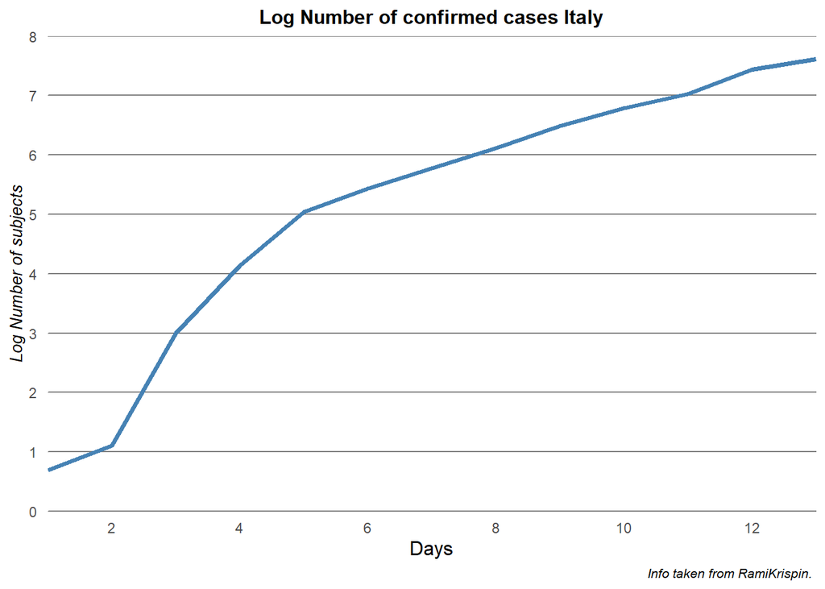

```r
PlotItalylog <- ggplot(c4, aes(day, log(corcumtotal_cases))) + geom_line(size=1.25,color="steelblue")+
    theme(
    plot.title = element_text(size = 12, face = "bold",hjust = 0.5),
    plot.caption = element_text(size = 8, face = "italic"),
    panel.grid.minor = element_blank(),
    panel.grid.major = element_line(color = "gray50", size = 0.5),
    panel.grid.major.x = element_blank(),
    panel.background = element_blank(),
    line = element_blank(),
    axis.ticks.length = unit(.15, "cm"),
    axis.ticks.y = element_blank(),
    axis.title.x = element_text(color="black",
    size=12),
    axis.title.y = element_text(color="black",
    size=10,
    face="italic"))+

  scale_y_continuous(expand = c(0, 0),
    limits=c(0.0,8),
    breaks=seq(0.0,8,1),
    name = "Log Number of subjects")+

  scale_x_continuous(expand = c(0, 0),
    breaks=seq(0.0,13,2),
    name = "Days")+

  labs(title = "Log Number of confirmed cases Italy",
       caption = "Info taken from RamiKrispin. ")
PlotItalylog
```

In fact, if we take a look at the first 12 days in China we do get a fairly similiar picture in terms of increments, albeit, with much higher numbers.

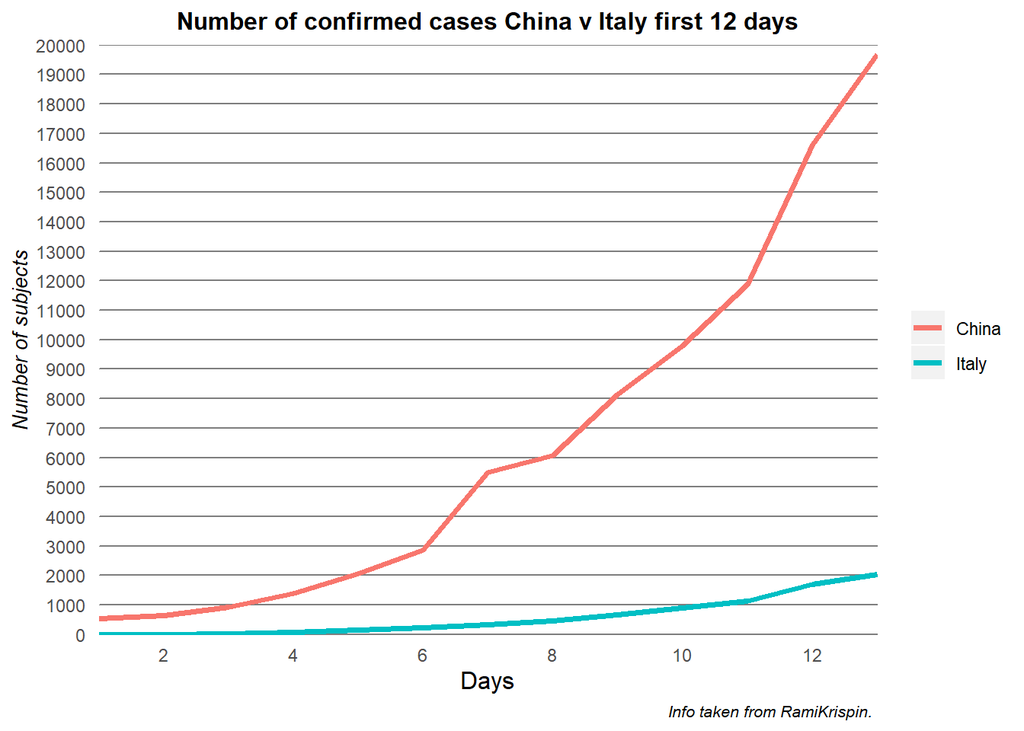

```r
c5 <- c2[which(c2$day < 14),]
c5$corcumtotal_casesItaly  <- c4$corcumtotal_cases

PlotChinalin12 <- ggplot(c5, aes(day)) + geom_line(aes(y = corcumtotal_cases, colour = "China"),size = 1.25  ) + geom_line(aes(y = corcumtotal_casesItaly, colour = "Italy"),size = 1.25 )+

  theme(
    plot.title = element_text(size = 12, face = "bold",hjust = 0.5),
    plot.caption = element_text(size = 8, face = "italic"),
    panel.grid.minor = element_blank(),
    panel.grid.major = element_line(color = "gray50", size = 0.5),
    panel.grid.major.x = element_blank(),
    panel.background = element_blank(),
    legend.title = element_blank(),
    line = element_blank(),
    axis.ticks.length = unit(.15, "cm"),
    axis.ticks.y = element_blank(),
    axis.title.x = element_text(color="black",
    size=12),
    axis.title.y = element_text(color="black",
    size=10,
    face="italic"))+

  scale_y_continuous(expand = c(0, 0),
    limits=c(0.0,20000),
    breaks=seq(0.0,20000,1000),
    name = "Number of subjects")+

  scale_x_continuous(expand = c(0, 0),
    breaks=seq(0.0,13,2),
    name = "Days")+

  labs(title = "Number of confirmed cases China v Italy first 12 days",
       caption = "Info taken from RamiKrispin. ")
PlotChinalin12
```

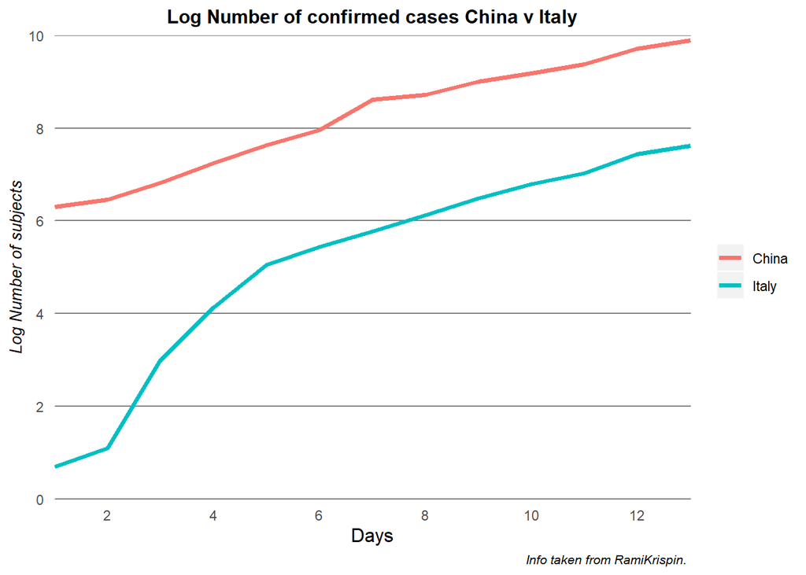

```r
PlotChinaItalog12 <- ggplot(c5, aes(day)) + geom_line(aes(y = log(corcumtotal_cases), colour = "China"),size = 1.25  ) + geom_line(aes(y = log(corcumtotal_casesItaly), colour = "Italy"),size = 1.25 )+

  theme(
    plot.title = element_text(size = 12, face = "bold",hjust = 0.5),
    plot.caption = element_text(size = 8, face = "italic"),
    panel.grid.minor = element_blank(),
    panel.grid.major = element_line(color = "gray50", size = 0.5),
    panel.grid.major.x = element_blank(),
    panel.background = element_blank(),
    legend.title = element_blank(),
    line = element_blank(),
    axis.ticks.length = unit(.15, "cm"),
    axis.ticks.y = element_blank(),
    axis.title.x = element_text(color="black",
    size=12),
    axis.title.y = element_text(color="black",
    size=10,
    face="italic"))+

  scale_y_continuous(expand = c(0, 0),
    limits=c(0.0,10),
    breaks=seq(0.0,10,2),
    name = "Log Number of subjects")+

  scale_x_continuous(expand = c(0, 0),
    breaks=seq(0.0,13,2),
    name = "Days")+

  labs(title = "Log Number of confirmed cases China v Italy",
       caption = "Info taken from RamiKrispin. ")

PlotChinaItalog12
```

The overall numbers seem to be slowing down as China appears to be getting it under control, however when looking at the individual pictures we find that there is still a lot of work to be done over the world.